# Bellabeat Smart Device usage trend analysis

Ernesto Uribe Cabrera

2025-03-26

# introduction

Bellabeat is a tech company with the mission of improving womens health with smart devices that look stylish and great. They are a relevant character in the smart device market and strive to improve and grow!

# Business task

Analyze smart device usage data in order to gain insight into how consumers use non-Bellabeat smart devices. Meaning to answer and gather usefull insight from the following questions as a guide of the analysis, in order to make improvements to a Bellabeat product.

1. What are some trends in smart device usage?
2. How could these trends apply to Bellabeat customers?
3. How could these trends help influence Bellabeat marketing strategy?

First, we load the packages we need.

```r
library(tidyverse)
library(lubridate)
library(janitor)
library(readr)
```

Then the files from the dataset, i may not need them all, but just in case.

```r
daily_activity <- read_csv("dailyActivity_merged.csv") %>% clean_names()
calories_hourly <- read_csv("hourlyCalories_merged.csv") %>% clean_names()
sleep <- read_csv("minuteSleep_merged.csv") %>% clean_names()
```

Here i cleaned the data a bit with “clean_names”. Data was taken from a kaggle zip folder with many files from a study of 30 users of fitbit smart devices. Measuring around 7 different user variables detected by the smart device. As the sample size is low its reliability is limited, i would hesitate to make sure assumptions with this. Although the data about each user is a lot, so we are able to spot some patterns.

Next i will explore the relationship between sleep and calories burned the day the user wakes up. The hypothesis being that, if a person sleeps better it will be more active and thus burn more calories in the day.

# Sleep vs Calories burned

## Prepare sleep and calories data

```r
### Convert sleep datetime and extract date only
sleep$date <- as.POSIXct(sleep$date, format = "%m/%d/%Y %I:%M:%S %p")
sleep$datex <- as.Date(sleep$date)

### Aggregate minutes asleep per user per date
sleep_minutes_daily <- sleep %>%
  group_by(id, datex) %>%
  summarise(minutes_asleep = sum(value), .groups = "drop") %>%
  rename(activity_date = datex)

### Preview
head(sleep_minutes_daily)
```

```
## # A tibble: 6 × 3
##           id activity_date minutes_asleep
##        <dbl> <date>                 <dbl>
## 1 1503960366 2016-03-13               441
## 2 1503960366 2016-03-14               423
## 3 1503960366 2016-03-15               365
## 4 1503960366 2016-03-16               404
## 5 1503960366 2016-03-17               473
## 6 1503960366 2016-03-18               449
```

```r
### Convert calories datetime and keep date only
calories_hourly$activity_hour <- as.POSIXct(
  calories_hourly$activity_hour,
  format = "%m/%d/%Y %I:%M:%S %p"
)

calories_hourly$date <- as.Date(calories_hourly$activity_hour)

### Sum total calories per user per day
daily_calories <- calories_hourly %>%
  group_by(id, date) %>%
  summarise(total_calories = sum(calories), .groups = "drop") %>%
  rename(activity_date = date)

### Preview
head(daily_calories)
```

```
## # A tibble: 6 × 3
##           id activity_date total_calories
##        <dbl> <date>                 <dbl>
## 1 1503960366 2016-03-12              2228
## 2 1503960366 2016-03-13              2100
## 3 1503960366 2016-03-14              1830
## 4 1503960366 2016-03-15              2111
## 5 1503960366 2016-03-16              1967
## 6 1503960366 2016-03-17              2039
```

## Join Sleep and Calories Data

```r
sleep_calories <- inner_join(sleep_minutes_daily, daily_calories, by = c("id", "activity_date"))

### Preview result
head(sleep_calories)
```

```
## # A tibble: 6 × 4
##           id activity_date minutes_asleep total_calories
##        <dbl> <date>                 <dbl>          <dbl>
## 1 1503960366 2016-03-13               441           2100
## 2 1503960366 2016-03-14               423           1830
## 3 1503960366 2016-03-15               365           2111
## 4 1503960366 2016-03-16               404           1967
## 5 1503960366 2016-03-17               473           2039
## 6 1503960366 2016-03-18               449           2002
```

## Now, a visualization of the joint data: Sleep vs. Calories

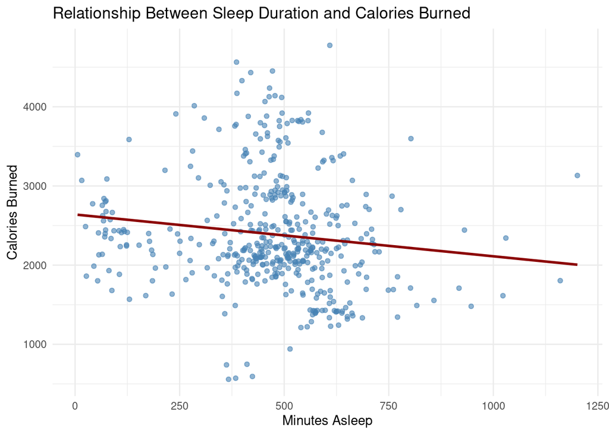

```r
ggplot(sleep_calories, aes(x = minutes_asleep, y = total_calories)) +
  geom_point(alpha = 0.6, color = "steelblue") +
  geom_smooth(method = "lm", se = FALSE, color = "darkred") +
  labs(
    title = "Relationship Between Sleep Duration and Calories Burned",
    x = "Minutes Asleep",
    y = "Calories Burned"
  ) +
  theme_minimal()
```

We see a slight negative relationship between amount of sleep and calories burned. While this doesn’t help us gain insights, it lets us focus on other hypothesis.

# Steps vs sleep amount at night

## Prepare steps data

```r
steps_sleep <- daily_activity %>%
  select(id, activity_date, total_steps) %>%
  mutate(activity_date = mdy(activity_date)) %>%
  mutate(sleep_date = activity_date + 1)  ### I arranged the data so that the sleep that starts one night ends the day after.
```

```r
### Join with sleep data
steps_sleep_joined <- inner_join(steps_sleep, sleep_minutes_daily, by = c("id", "sleep_date" = "activity_date"))

### Preview result
head(steps_sleep_joined)
```

```
## # A tibble: 6 × 5
##           id activity_date total_steps sleep_date minutes_asleep
##        <dbl> <date>              <dbl> <date>              <dbl>
## 1 1503960366 2016-03-25          11004 2016-03-26            511
## 2 1503960366 2016-03-26          17609 2016-03-27            533
## 3 1503960366 2016-03-27          12736 2016-03-28             81
## 4 1503960366 2016-03-28          13231 2016-03-29            411
## 5 1503960366 2016-03-30          10970 2016-03-31            365
## 6 1503960366 2016-03-31          12256 2016-04-01            333
```

## Visualize steps vs. night sleep

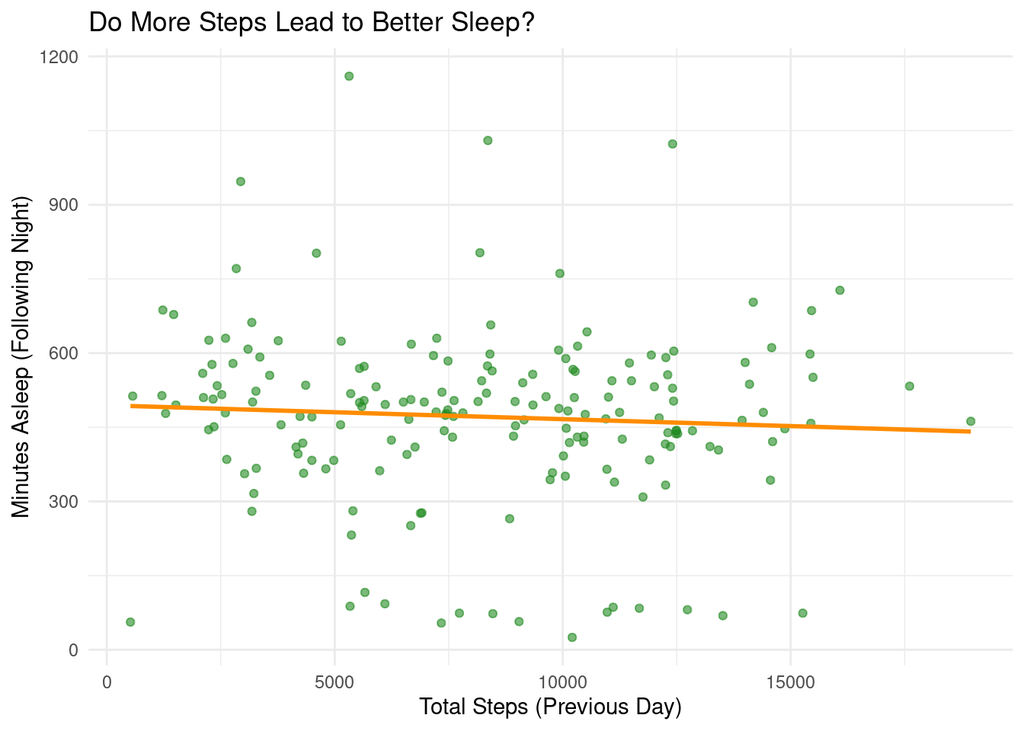

```r
ggplot(steps_sleep_joined, aes(x = total_steps, y = minutes_asleep)) +
  geom_point(alpha = 0.6, color = "forestgreen") +
  geom_smooth(method = "lm", se = FALSE, color = "darkorange") +
  labs(
    title = "Do More Steps Lead to Better Sleep?",
    x = "Total Steps (Previous Day)",
    y = "Minutes Asleep (Following Night)"
  ) +
  theme_minimal()
```

This shows a very slight negative correlation between steps and sleep at night. Again, data sample is very small, so veracity might be an issue. In any case, for now we can see that sleep patterns are not an area of opportunity in this case (data).

I will continue to analyze average steps per weekday in case there is a pattern Bellabeat can use to improve its users lives.

```r
### Prepare weekday data from daily_activity
weekday_steps <- daily_activity %>%
  mutate(activity_date = mdy(activity_date)) %>%
  mutate(weekday = wday(activity_date, label = TRUE, abbr = FALSE)) %>%
  group_by(weekday) %>%
  summarise(avg_steps = mean(total_steps, na.rm = TRUE), .groups = "drop")

### Preview
head(weekday_steps)
```

```
## # A tibble: 6 × 2
##   weekday   avg_steps
##   <ord>         <dbl>
## 1 Sunday        6058.
## 2 Monday        7119.
## 3 Tuesday       4915.
## 4 Wednesday     7511.
## 5 Thursday      6847.
## 6 Friday        6738.
```

With this we can already see something but let’s make it more visual!

## Visualize average steps by weekday

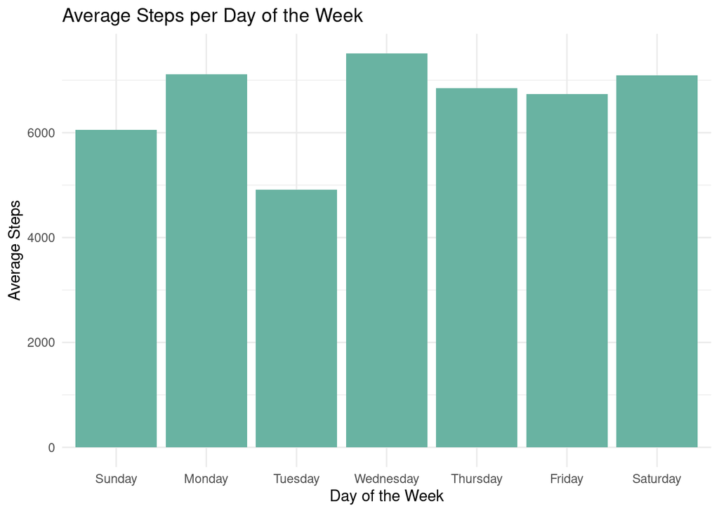

```r
ggplot(weekday_steps, aes(x = weekday, y = avg_steps)) +
  geom_col(fill = "#69b3a2") +
  labs(
    title = "Average Steps per Day of the Week",
    x = "Day of the Week",
    y = "Average Steps"
  ) +
  theme_minimal()
```

Tuesday seems to have noticeable dip, compared to other days.

In this dataset analysis, sleep patterns did not show strong or actionable trends. Nonetheless the analysis helped narrow down areas of opportunity, thus we were able to find a pattern in steps across the weekdays.

Tuesday showed the lowest average step count among all weekdays. Some actions Bellabeat could take with this information are: - Mid-week motivational challenges - Personalized step reminders on Tuesdays - Community-based encouragement to boost early-week activity

By aligning smart device feedback and notifications with actual user behavior trends, Bellabeat can drive more consistent engagement and support healthier habits.

**Conclusion:**  
Patterns didn’t match initial expectations but we still managed to arrive at valuable insights. Interpretations, features or any value added from data gathered out of Bellabeat smart devices can be a big plus factor for Bellabeat in the smart devises market. As well as data analysis in any other market.